# Clustering Aplicado Para Analisis Pensiones Basicas Solidarias de Vejez PBSV

Trabajo final Diplomado Big Data para politicas publicas

José Luis Toro

21 de Diciembre de 2018

Verificamos directorio actual

```r
getwd()
```

```
## [1] "F:/archivo base Potenciales PBSV/data/FINAL"
```

Modificamos el directorio de trabajo correspondiente

```r
setwd("F:/archivo base Potenciales PBSV/data/FINAL")
```

Instalamos algunas librerias necesarias

```r
#install.packages("lattice")
install.packages("ggplot2")
install.packages("caret")
install.packages("e1071")
install.packages("gmodels")
install.packages("dplyr")
install.packages("factoextra")
install.packages("NbClust")

library(lattice)
library(ggplot2)
library(caret)
library(e1071)
library(gmodels)
library(dplyr)
library(factoextra)
library(NbClust)
```

# Exploracion

### Cargamos los datos y realizamos un breve analisis de los datos.

```r
Potenciales = read.csv('Potenciales_PBSV_regionmetropol_v2.csv', dec=',')
str(Potenciales)
```

```
## 'data.frame':    8154 obs. of  17 variables:
##  $ ID               : Factor w/ 8154 levels "BAACEFCI","BAAJEAG",..: 7449 1547 2633 7652 4477 2482 3759 1235 1918 5551 ...
##  $ Periodo          : Factor w/ 10 levels "01-01-2017","01-02-2017",..: 9 1 1 7 7 1 1 3 3 7 ...
##  $ MID_CALLE        : Factor w/ 4632 levels " ESTERO CODEGUA",..: 2159 428 1511 1511 1511 2821 2821 4486 4299 1060 ...
##  $ MID_NRO_DOMI     : int  904 391 150 15 20 700 700 175 141 100 ...
##  $ Comuna_Fmt_google: Factor w/ 51 levels "Alhue","Buin",..: 50 50 50 50 50 50 50 50 50 50 ...
##  $ C_REGION         : int  13 13 13 13 13 13 13 13 13 13 ...
##  $ FECHA_NACIMIENTO : Factor w/ 4909 levels "01-01-1926","01-01-1929",..: 1879 2883 221 2014 2026 426 1691 4046 1780 2174 ...
##  $ EDAD             : int  67 82 82 65 67 82 70 84 80 69 ...
##  $ SEXO             : int  2 2 2 1 1 2 1 2 2 2 ...
##  $ FPS              : int  14596 14596 8499 8499 14596 11733 11733 12665 14596 14235 ...
##  $ PFP              : int  797 548 204 0 1112 0 0 922 1048 1192 ...
##  $ YHL              : int  0 0 0 0 14594 0 0 0 0 0 ...
##  $ YOI              : int  0 0 0 0 0 0 0 0 0 0 ...
##  $ YKL              : int  0 0 0 0 0 0 0 0 0 0 ...
##  $ AFPER2018        : int  0 0 0 0 0 0 0 0 0 0 ...
##  $ LAT              : Factor w/ 7453 levels "-33.0758938",..: 1 2 3 4 5 6 6 6 6 6 ...
##  $ LON              : Factor w/ 7443 levels "-70.2791133",..: 7289 7281 7290 7286 7284 7285 7285 7285 7285 7285 ...
```

```r
summary(Potenciales)
```

```
##         ID             Periodo                       MID_CALLE
##  BAACEFCI:   1   01-01-2017:4062   AVENIDA CRISTOBAL COLON:  24
##  BAAJEAG :   1   01-07-2017:1034   ARTURO PRAT            :  22
##  BAAJHCIC:   1   01-03-2017: 841   MANUEL RODRIGUEZ       :  19
##  BAAJHEGB:   1   01-10-2018: 578   MAIPU                  :  17
##  BAAJJFJC:   1   01-02-2017: 505   SAN FRANCISCO          :  17
##  BADAJDGJ:   1   01-04-2017: 382   PASAJE 1               :  16
##  (Other) :8148   (Other)   : 752   (Other)                :8039
##   MID_NRO_DOMI       Comuna_Fmt_google    C_REGION    FECHA_NACIMIENTO
##  Min.   :     1   Maipu       : 634    Min.   :13   29-08-1953:  13
##  1st Qu.:   700   La Florida  : 542    1st Qu.:13   20-09-1953:  11
##  Median :  1710   Puente Alto : 501    Median :13   17-01-1952:   8
##  Mean   :  3135   Las Condes  : 495    Mean   :13   02-01-1952:   7
##  3rd Qu.:  4672   Santiago    : 389    3rd Qu.:13   02-08-1952:   7
##  Max.   :183652   San Bernardo: 294    Max.   :13   06-09-1953:   7
##                   (Other)     :5299                 (Other)   :8101
##       EDAD             SEXO            FPS             PFP
##  Min.   : 65.00   Min.   :1.000   Min.   : 8499   Min.   :-12340.0
##  1st Qu.: 67.00   1st Qu.:1.000   1st Qu.: 8499   1st Qu.:     0.0
##  Median : 71.00   Median :2.000   Median :11733   Median :   305.0
##  Mean   : 74.01   Mean   :1.735   Mean   :11653   Mean   :   418.4
##  3rd Qu.: 78.00   3rd Qu.:2.000   3rd Qu.:14235   3rd Qu.:   796.0
##  Max.   :143.00   Max.   :2.000   Max.   :16315   Max.   :  8336.0
##                                   NA's   :8
##       YHL              YOI               YKL             AFPER2018
##  Min.   :     0   Min.   :      0   Min.   :-5107205   Min.   :0.00000
##  1st Qu.:     0   1st Qu.:      0   1st Qu.:       0   1st Qu.:0.00000
##  Median :     0   Median :      0   Median :       0   Median :0.00000
##  Mean   :  7560   Mean   :   2725   Mean   :    5963   Mean   :0.01042
##  3rd Qu.:     0   3rd Qu.:      0   3rd Qu.:       0   3rd Qu.:0.00000
##  Max.   :784697   Max.   :5105386   Max.   : 1134076   Max.   :1.00000
##
##           LAT                LON
##  -33.5226882:  32   -70.5987142:  33
##  -33.5854485:  25   -70.6987361:  25
##  -33.4216593:  20   -70.7346887:  20
##  -33.5209155:  20   -70.7631335:  20
##  -33.7309374:  19   -70.7423218:  19
##  -33.2827093:  17   -70.879328 :  17
##  (Other)    :8021   (Other)    :8020
```

### Haremos una sustitucion de los valores NA en todo el dataset.

```r
#acá le asigna el valor 0 a los NA
Potenciales[is.na(Potenciales)]<-0
```

# Clustering

## Realizaremos el Clustering del dataset utilizado

### Transformamos a valores numericos las variables a ingresar a la funcion kmeans.

```r
atributos <- Potenciales[8:15]

atributos_norm <- as.data.frame(lapply(atributos, scale))
```

### Ahora procedemos a buscar clusters:

```r
set.seed(0)
clusters <- kmeans(atributos_norm, 6)
```

### Vemos el tamano de cada cluster:

```r
clusters$size
```

```
## [1] 1673 1190 1667  719  874 2031
```

### Procedemos a analizar cada cluster, a traves de los centroides

```r
clusters$centers
```

```
##         EDAD        SEXO        FPS        PFP        YHL         YOI
## 1 -0.1478713  0.59988538 -1.2120054 -0.2071626 -0.1048123 -0.03969653
## 2 -0.3064019 -1.54487596  0.6637459 -0.1164202  0.6669238  0.20329883
## 3 -0.2537387  0.59988538  0.7229021 -0.5971837 -0.1120207 -0.03076056
## 4  2.2105996 -0.01800968 -0.4845762 -0.5226275 -0.1436002 -0.04594839
## 5 -0.2889735 -1.55266935 -1.1535031 -0.5108789 -0.1253642 -0.00554698
## 6 -0.1486307  0.59318917  0.6840579  1.1338777 -0.1076972 -0.04251626
##           YKL  AFPER2018
## 1 -0.02381828 -0.1026297
## 2  0.02300369 -0.0943564
## 3 -0.07357840 -0.1026297
## 4 -0.04426930 -0.1026297
## 5 -0.02160293  0.8435914
## 6  0.09150142 -0.1026297
```

### Visualizamos los centroides

```r
View(clusters$centers)
```

### Agregamos la columna del cluster al dataset original:

```r
Potenciales$cluster <- as.factor(clusters$cluster)
#View(Potenciales)
```

### Exportamos el dataset para realizar analisis visual:

```r
write.csv(Potenciales, file="clasif_potenciales.csv")
```

### Dados estos nuevos datos, podemos examinar como el cluster se relaciona con cada caracteristica.

```r
#aggregate(data = Potenciales, Population ~ cluster, mean)
```

### Verificamos si la cantidad de cluster indicados es la mejor

```r
library(dplyr)
s=sample_n(atributos_norm, 100)
```

```r
library(factoextra)
```

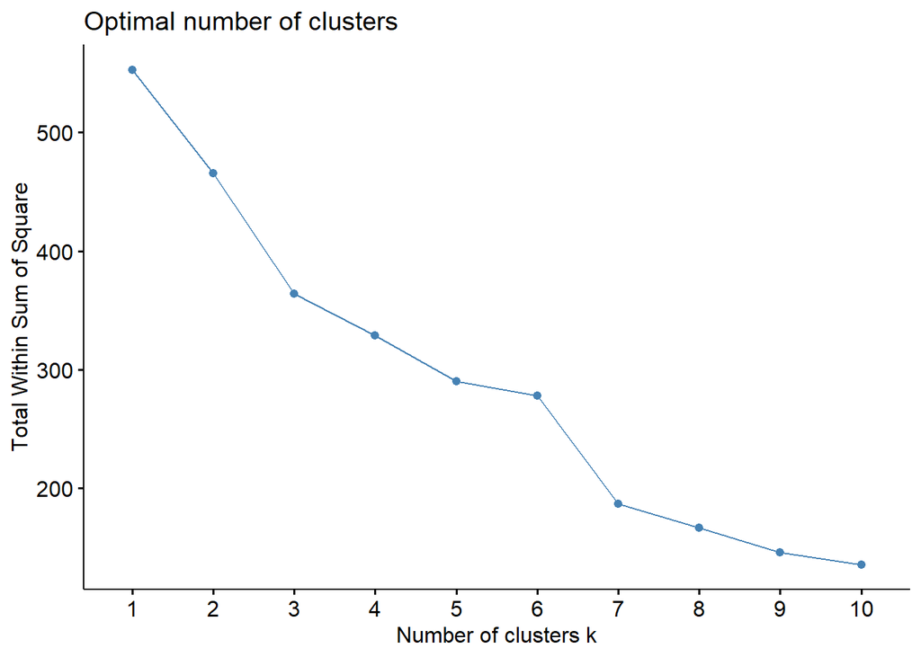

```r
fviz_nbclust(s, kmeans, method = "wss", k.max=10)
```

```r
library(NbClust)
nb <- NbClust(s, distance = "euclidean", min.nc = 2,
        max.nc = 7, method = "kmeans")
```

[output not shown]

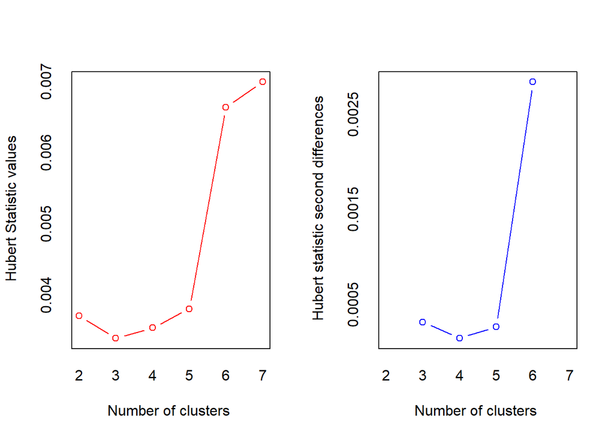

```
## *** : The Hubert index is a graphical method of determining the number of clusters.
##                 In the plot of Hubert index, we seek a significant knee that corresponds to a
##                 significant increase of the value of the measure i.e the significant peak in Hubert
##                 index second differences plot.
##
```

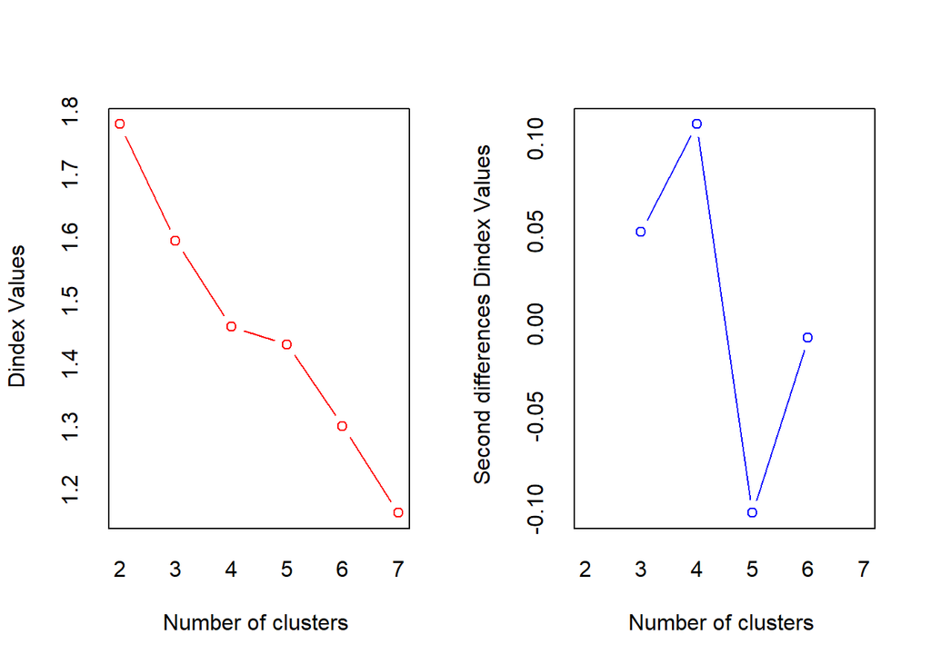

```
## *** : The D index is a graphical method of determining the number of clusters.
##                 In the plot of D index, we seek a significant knee (the significant peak in Dindex
##                 second differences plot) that corresponds to a significant increase of the value of
##                 the measure.
##
## * Among all indices:
## * 5 proposed 2 as the best number of clusters
## * 5 proposed 3 as the best number of clusters
## * 2 proposed 4 as the best number of clusters
## * 2 proposed 5 as the best number of clusters
## * 7 proposed 6 as the best number of clusters
## * 3 proposed 7 as the best number of clusters
##
##                    ***** Conclusion *****
##
## * According to the majority rule, the best number of clusters is  6
##
##
```

```
## Among all indices:
## ===================
## * 2 proposed  0 as the best number of clusters
## * 5 proposed  2 as the best number of clusters
## * 5 proposed  3 as the best number of clusters
## * 2 proposed  4 as the best number of clusters
## * 2 proposed  5 as the best number of clusters
## * 7 proposed  6 as the best number of clusters
## * 3 proposed  7 as the best number of clusters
##
## Conclusion
## =========================
## * According to the majority rule, the best number of clusters is  6 .
```

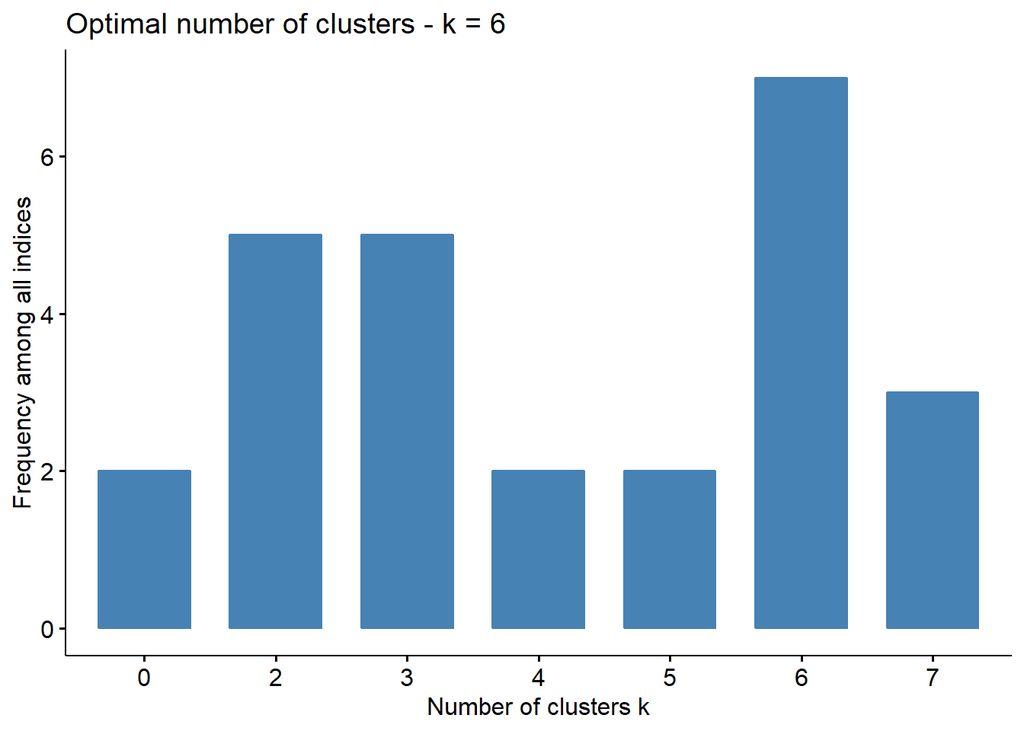

```r
fviz_nbclust(nb)
```

####Segun el analisis realizado el numero recomendado de cluster es de 6.

# Arbol de decision

### Entrenamiento

#### Realizamos el entrenamiento del modelo en base al archivo de potenciales y los cluster definidos a traves del proceso k-means

```r
library(C50)
modelo = C5.0(atributos, Potenciales$cluster)
predicciones <- predict(modelo, atributos)
View(predicciones)
```

### Revisamos el modelo generado a traves de diversas formas visuales

```r
modelo
```

```
##
## Call:
## C5.0.default(x = atributos, y = Potenciales$cluster)
##
## Classification Tree
## Number of samples: 8154
## Number of predictors: 8
##
## Tree size: 54
##
## Non-standard options: attempt to group attributes
```

```r
summary(modelo) #entrega el arbol como texto
```

```
##
## Call:
## C5.0.default(x = atributos, y = Potenciales$cluster)
##
##
## C5.0 [Release 2.07 GPL Edition]      Tue Nov 27 17:22:23 2018
## -------------------------------
##
## Class specified by attribute `outcome'
##
## Read 8154 cases (9 attributes) from undefined.data
##
## Decision tree:
##
## FPS <= 8499:
## :...EDAD <= 84:
## :   :...SEXO <= 1:
## :   :   :...YHL <= 78852: 5 (775/1)
## :   :   :   YHL > 78852: 2 (22/3)
## :   :   SEXO > 1:
## :   :   :...AFPER2018 > 0: 5 (31)
## :   :       AFPER2018 <= 0:
## :   :       :...PFP <= 1177: 1 (1645/1)
## :   :           PFP > 1177:
## :   :           :...PFP <= 1334: 1 (15/1)
## :   :               PFP > 1334: 6 (10)
## :   EDAD > 84:
## :   :...EDAD > 86: 4 (373/2)
## :       EDAD <= 86:
## :       :...SEXO <= 1: 5 (32)
## :           SEXO > 1:
## :           :...PFP <= 519: 4 (60/1)
## :               PFP > 519:
## :               :...EDAD <= 85: 1 (10)
## :                   EDAD > 85:
## :                   :...PFP <= 740: 4 (4)
## :                       PFP > 740: 1 (5/1)
## FPS > 8499:
## :...AFPER2018 > 0: 5 (33/1)
##     AFPER2018 <= 0:
```

[output cut: 98 more lines]

```
##       2     2     1     1     1  2024    (f): class 6
##
##
##  Attribute usage:
##
##  100.00% FPS
##   98.77% EDAD
##   95.02% SEXO
##   84.29% AFPER2018
##   82.56% PFP
##   58.19% YHL
##   19.48% YKL
##
##
## Time: 0.0 secs
```

[figure not shown]

```r
plot(modelo)  #dibuja el modelo
```

[figure not shown]

```r
plot(modelo, type="simple") #dibuja el modelo y nos da el numero de cluster
```

### CrossTable

#### Realizamos el analisis del modelo generado, comparando el cluster generado por k-means y la prediccion realizada por el arbol de decision.

```r
library(gmodels)
CrossTable(x=Potenciales$cluster,y=predicciones,prop.chisq=FALSE)
```

```
##
##
##    Cell Contents
## |-------------------------|
## |                       N |
## |           N / Row Total |
## |           N / Col Total |
## |         N / Table Total |
## |-------------------------|
##
##
## Total Observations in Table:  8154
##
##
##                     | predicciones
## Potenciales$cluster |         1 |         2 |         3 |         4 |         5 |         6 | Row Total |
## --------------------|-----------|-----------|-----------|-----------|-----------|-----------|-----------|
##                   1 |      1672 |         0 |         0 |         1 |         0 |         0 |      1673 |
##                     |     0.999 |     0.000 |     0.000 |     0.001 |     0.000 |     0.000 |     0.205 |
##                     |     0.998 |     0.000 |     0.000 |     0.001 |     0.000 |     0.000 |           |
##                     |     0.205 |     0.000 |     0.000 |     0.000 |     0.000 |     0.000 |           |
## --------------------|-----------|-----------|-----------|-----------|-----------|-----------|-----------|
##                   2 |         1 |      1184 |         0 |         3 |         1 |         1 |      1190 |
##                     |     0.001 |     0.995 |     0.000 |     0.003 |     0.001 |     0.001 |     0.146 |
##                     |     0.001 |     0.994 |     0.000 |     0.004 |     0.001 |     0.000 |           |
##                     |     0.000 |     0.145 |     0.000 |     0.000 |     0.000 |     0.000 |           |
## --------------------|-----------|-----------|-----------|-----------|-----------|-----------|-----------|
##                   3 |         0 |         1 |      1664 |         0 |         0 |         2 |      1667 |
##                     |     0.000 |     0.001 |     0.998 |     0.000 |     0.000 |     0.001 |     0.204 |
##                     |     0.000 |     0.001 |     0.999 |     0.000 |     0.000 |     0.001 |           |
##                     |     0.000 |     0.000 |     0.204 |     0.000 |     0.000 |     0.000 |           |
## --------------------|-----------|-----------|-----------|-----------|-----------|-----------|-----------|
##                   4 |         0 |         1 |         1 |       715 |         0 |         2 |       719 |
##                     |     0.000 |     0.001 |     0.001 |     0.994 |     0.000 |     0.003 |     0.088 |
##                     |     0.000 |     0.001 |     0.001 |     0.990 |     0.000 |     0.001 |           |
##                     |     0.000 |     0.000 |     0.000 |     0.088 |     0.000 |     0.000 |           |
## --------------------|-----------|-----------|-----------|-----------|-----------|-----------|-----------|
##                   5 |         0 |         3 |         0 |         2 |       869 |         0 |       874 |
##                     |     0.000 |     0.003 |     0.000 |     0.002 |     0.994 |     0.000 |     0.107 |
##                     |     0.000 |     0.003 |     0.000 |     0.003 |     0.998 |     0.000 |           |
##                     |     0.000 |     0.000 |     0.000 |     0.000 |     0.107 |     0.000 |           |
## --------------------|-----------|-----------|-----------|-----------|-----------|-----------|-----------|
##                   6 |         2 |         2 |         1 |         1 |         1 |      2024 |      2031 |
##                     |     0.001 |     0.001 |     0.000 |     0.000 |     0.000 |     0.997 |     0.249 |
##                     |     0.001 |     0.002 |     0.001 |     0.001 |     0.001 |     0.998 |           |
##                     |     0.000 |     0.000 |     0.000 |     0.000 |     0.000 |     0.248 |           |
## --------------------|-----------|-----------|-----------|-----------|-----------|-----------|-----------|
##        Column Total |      1675 |      1191 |      1666 |       722 |       871 |      2029 |      8154 |
##                     |     0.205 |     0.146 |     0.204 |     0.089 |     0.107 |     0.249 |           |
## --------------------|-----------|-----------|-----------|-----------|-----------|-----------|-----------|
##
##
```

### Matriz de confusion

#### Continuamos analizando los clusters definidos y las predicciones de clusters del arbol de decision.

```r
install.packages("caret")
install.packages("lattice")
library(lattice)
library(caret)
confusionMatrix( predicciones, Potenciales$cluster)
```

[output not shown]

### El modelo nos entrega una gran precision para la prediccion sobre los cluster.

# Cluster Jerarquico

Debido a que especificar el número de clústeres, y encontrar el número óptimo de clústeres resulta una tarea complicada. La agrupación jerárquica es un metodo alternativo que construye una jerarquia de abajo hacia arriba y no requiere que especifiquemos el número de clusteres de antemano.

El algoritmo funciona los dos cluster más cercanos y los combina en un solo grupo.

Generalmente se representa mediante una estructura de dendrograma.

Hay diferentes formas de determinar que tan cerca esten dos clústeres:

- Agrupación completa de enlaces: encuentra la distancia máxima posible entre los puntos que pertenecen a dos grupos diferentes.
- Agrupación de enlaces individuales: encuentra la distancia mínima posible entre los puntos que pertenecen a dos grupos diferentes.
- Agrupación media de enlaces: encuentra todas las distancias posibles en pares para los puntos que pertenecen a dos grupos diferentes y luego calcula el promedio.
- Agrupación de vinculación de centroide: encuentra el centroide de cada agrupacion y calcula la distancia entre los centroides de dos agrupaciones.

```r
clusters_jerarq <- hclust (dist (atributos))
plot (clusters_jerarq)
```

[output not shown]

```r
clusterCut <- cutree (clusters_jerarq, 10)
table (clusterCut, Potenciales$cluster)
```

[output not shown]

### Utilizamos agrupación de vinculación de centroide:

```r
clusters_jerarq <- hclust (dist (atributos), method  = 'centroid')
 plot (clusters_jerarq)
```

[output not shown]

```r
library(ggplot2)
 ggplot (atributos, aes (Potenciales$cluster, Potenciales$Comuna_Fmt_google, color = Potenciales$cluster)) +
   geom_point (alpha = 0.4, size = 3.5) + geom_point (col = clusterCut) +
   scale_color_manual (values= c ('black', 'red', 'green','blue', 'pink', 'yellow','grey', 'purple', 'brown','orange'))
```

[output not shown]

```r
hc <- hclust(dist(atributos), "cen")
memb <- cutree(hc, k = 10)
cent <- NULL
for(k in 1:10){
  cent <- rbind(cent, colMeans(atributos[memb == k, , drop = FALSE]))
}
hc1 <- hclust(dist(cent), method = "cen", members = table(memb))
opar <- par(mfrow = c(1, 2))
plot(hc,  labels = FALSE, hang = -1, main = "Original Tree")
plot(hc1, labels = FALSE, hang = -1, main = "Re-start from 10 clusters")
par(opar)
```

[output not shown]